# version2_revision

## Load Data & Initial Inspection

```python
import pandas as pd
import numpy as np
import matplotlib.pyplot as plt
import seaborn as sns
import warnings
warnings.filterwarnings('ignore')
```

```python
# Define the path to the dataset
PATH = 'Dollar_Rial_Price_Dataset.csv'

# Load the dataset
df = pd.read_csv(PATH)

# Display the first few rows of the dataset
df.head()
```

|  | Open Price | Low Price | High Price | Close Price | Change Amount | Change Percent | Gregorian Date | Persian Date |
| --- | --- | --- | --- | --- | --- | --- | --- | --- |
| 0 | 1073800 | 1073800 | 1089200 | 1088700 | 15700 | 1.46% | 2025/11/01 | 1404/08/10 |
| 1 | 1071300 | 1071300 | 1076700 | 1073000 | 3900 | 0.36% | 2025/10/30 | 1404/08/08 |
| 2 | 1069050 | 1066800 | 1074700 | 1069100 | 200 | 0.02% | 2025/10/29 | 1404/08/07 |
| 3 | 1078550 | 1069300 | 1083200 | 1069300 | 10500 | 0.98% | 2025/10/28 | 1404/08/06 |
| 4 | 1079150 | 1077300 | 1086200 | 1079800 | 1400 | 0.13% | 2025/10/27 | 1404/08/05 |

```python
df.shape
```

```
(3695, 8)
```

```python
df.info()
```

```
<class 'pandas.core.frame.DataFrame'>
RangeIndex: 3695 entries, 0 to 3694
Data columns (total 8 columns):
 #   Column          Non-Null Count  Dtype
---  ------          --------------  -----
 0   Open Price      3695 non-null   int64
 1   Low Price       3695 non-null   int64
 2   High Price      3695 non-null   int64
 3   Close Price     3695 non-null   int64
 4   Change Amount   3695 non-null   object
 5   Change Percent  3695 non-null   object
 6   Gregorian Date  3695 non-null   object
 7   Persian Date    3695 non-null   object
dtypes: int64(4), object(4)
memory usage: 231.1+ KB
```

```python
df.describe().T.round(2).style.format('{:,.2f}')
```

|  | count | mean | std | min | 25% | 50% | 75% | max |
| --- | --- | --- | --- | --- | --- | --- | --- | --- |
| Open Price | 3,695.00 | 229,552.92 | 259,048.77 | 13,440.00 | 34,540.00 | 119,600.00 | 310,425.00 | 1,170,550.00 |
| Low Price | 3,695.00 | 227,810.40 | 257,209.25 | 13,227.00 | 34,000.00 | 118,400.00 | 307,015.00 | 1,158,300.00 |
| High Price | 3,695.00 | 231,449.59 | 261,386.43 | 13,440.00 | 34,750.00 | 121,000.00 | 314,470.00 | 1,180,700.00 |
| Close Price | 3,695.00 | 229,683.76 | 259,364.62 | 13,350.00 | 34,295.00 | 119,450.00 | 310,028.00 | 1,178,600.00 |

```python
df.isnull().sum()
```

```
Open Price        0
Low Price         0
High Price        0
Close Price       0
Change Amount     0
Change Percent    0
Gregorian Date    0
Persian Date      0
dtype: int64
```

```python
df.duplicated().sum()
```

```
np.int64(0)
```

```python
# Convert all columns to lowercase and replace spaces with underscores
df.columns = df.columns.str.lower().str.replace(' ', '_')
df.columns.tolist()
```

```
['open_price',
 'low_price',
 'high_price',
 'close_price',
 'change_amount',
 'change_percent',
 'gregorian_date',
 'persian_date']
```

```python
# Drop persian_date column
df.drop(columns=['persian_date'], inplace=True)
```

```python
# Convert Gregorian Date to datetime format
df['gregorian_date'] = pd.to_datetime(df['gregorian_date'], format='%Y/%m/%d')

# Sort the DataFrame by date and reset the index
df.sort_values('gregorian_date', inplace=True)
df.reset_index(drop=True, inplace=True)

# Set Gregorian Date as the index
df.set_index('gregorian_date', inplace=True)
df.index.min(), df.index.max()
```

```
(Timestamp('2011-11-26 00:00:00'), Timestamp('2025-11-01 00:00:00'))
```

```python
df.head()
```

| gregorian_date | open_price | low_price | high_price | close_price | change_amount | change_percent |
| --- | --- | --- | --- | --- | --- | --- |
| 2011-11-26 | 13700 | 13700 | 13700 | 13700 | 260 | 1.93% |
| 2011-11-27 | 13440 | 13440 | 13440 | 13440 | 260 | 1.93% |
| 2011-11-28 | 13495 | 13227 | 13667 | 13350 | - | - |
| 2011-11-30 | 13580 | 13510 | 13830 | 13590 | 90 | 0.67% |
| 2011-12-03 | 13638 | 13504 | 13833 | 13623 | 13 | 0.1% |

```python
'''
    Recompute 'change_amount' & 'change_percentage' columns based due to data type and accuracy issues:
        - Both columns are read as object types, likely due to placeholder strings like '-' for missing values and '%' signs.
        - Existing values are inconsistently calculated, leading to inaccuracies.
    Calculation formulas:
        - change_amount = current_price - previous_price
        - change_percentage = (change_amount / previous_price) * 100
'''
df['previous_close'] = df['close_price'].shift(1)
df['change_amount'] = df['close_price'] - df['previous_close']
df['change_percent'] = (df['change_amount'] / df['previous_close']) * 100
df.drop(columns=['previous_close'], inplace=True)
df.dropna(inplace=True)
df.head()
```

| gregorian_date | open_price | low_price | high_price | close_price | change_amount | change_percent |
| --- | --- | --- | --- | --- | --- | --- |
| 2011-11-27 | 13440 | 13440 | 13440 | 13440 | -260.0 | -1.897810 |
| 2011-11-28 | 13495 | 13227 | 13667 | 13350 | -90.0 | -0.669643 |
| 2011-11-30 | 13580 | 13510 | 13830 | 13590 | 240.0 | 1.797753 |
| 2011-12-03 | 13638 | 13504 | 13833 | 13623 | 33.0 | 0.242826 |
| 2011-12-07 | 13494 | 13391 | 13658 | 13493 | -130.0 | -0.954269 |

```python
# Statistical summary after cleaning
df.describe().T.round(2).style.format('{:,.2f}')
```

|  | count | mean | std | min | 25% | 50% | 75% | max |
| --- | --- | --- | --- | --- | --- | --- | --- | --- |
| open_price | 3,694.00 | 229,611.35 | 259,059.48 | 13,440.00 | 34,540.00 | 119,615.00 | 310,437.50 | 1,170,550.00 |
| low_price | 3,694.00 | 227,868.36 | 257,219.94 | 13,227.00 | 34,000.00 | 118,450.00 | 307,057.50 | 1,158,300.00 |
| high_price | 3,694.00 | 231,508.54 | 261,397.25 | 13,440.00 | 34,750.00 | 121,019.00 | 314,755.00 | 1,180,700.00 |
| close_price | 3,694.00 | 229,742.23 | 259,375.37 | 13,350.00 | 34,300.00 | 119,475.00 | 310,029.00 | 1,178,600.00 |
| change_amount | 3,694.00 | 291.01 | 6,256.53 | -102,250.00 | -333.00 | 10.00 | 800.00 | 59,099.00 |
| change_percent | 3,694.00 | 0.14 | 2.11 | -16.32 | -0.38 | 0.02 | 0.58 | 19.45 |

## Exploratory Data Analysis (EDA)

```
Date Range: 2011-11-27 to 2025-11-01
Total Days: 5088, Observed Days: 3694, Missing Days: 1394
Data Frequency: Irregular
```

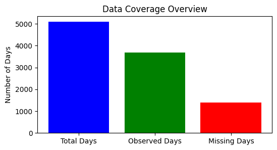

```python
# Check the data frequency and date range (expected: daily data with minimal missing dates due to weekends/holidays)

# Check date range and frequency
date_range = (df.index.min(), df.index.max())
total_days = (df.index.max() - df.index.min()).days
observed_days = df.shape[0]
missing_days = total_days - observed_days
frequency = 'Daily' if missing_days / total_days < 0.1 else 'Irregular'

# Print date range and frequency information
print(f"Date Range: {date_range[0].date()} to {date_range[1].date()}")
print(f"Total Days: {total_days}, Observed Days: {observed_days}, Missing Days: {missing_days}")
print(f"Data Frequency: {frequency}")

# Simple bar plot of total_days, observed_days, and missing_days
plt.figure(figsize=(6, 3))
plt.bar(['Total Days', 'Observed Days', 'Missing Days'], [total_days, observed_days, missing_days], color=['blue', 'green', 'red'])
plt.title('Data Coverage Overview')
plt.ylabel('Number of Days')
plt.show()
```

```python
# Find the missing dates and display them with their value counts
missing_dates = pd.date_range(start=date_range[0], end=date_range[1])
missing_dates = missing_dates.difference(df.index)
missing_days_of_week = missing_dates.to_series().dt.day_name().value_counts()
print(f"Missing Days of the Week: ({len(missing_dates)})\n{missing_days_of_week}")

## What percent of data is missing?
missing_percentage = (len(missing_dates) / total_days) * 100
print(f"\nPercentage of Missing Data: {missing_percentage:.2f}%")
```

```
Missing Days of the Week: (1395)
Friday       619
Thursday     437
Sunday        76
Saturday      73
Tuesday       71
Monday        66
Wednesday     53
Name: count, dtype: int64

Percentage of Missing Data: 27.42%
```

### Handling Irregular Frequency - Reindex using Iran's business week (Sat–Thu), forward-fill missing holidays, and keep Fridays excluded. (NOT DOING IT HERE).

The reason why I am choosing to not treat the irregular frequency is because one I reindex using Iran's business week (Sat-Thu), and forward-fill the missing holidays, keeping Fridays excluded, this creates a hyper-persistent series via reindex + forward-fill. That would mean literally copying yesterday's close across holidays and closures, inflating lag-1 autocorrelation. This would mislead any time series model to think the series is more predictable than it actually is. Hence, the model will be overfitted and perform poorly out-of-sample, copying the previous day's close price, not really learning any patterns. Therefore, I will keep the irregular frequency as is, and let the model learn from the actual data without artificial inflation of autocorrelation. For that, I will not use ARIMA. We'll use models that can handle irregular frequency better, such as Prophet, LSTM, or Random Forests.

```python
# Handling Irregular Frequency - Reindex using Iran's business week (Sat–Thu), forward-fill missing holidays, and keep Fridays excluded.
# iran_business_days = pd.bdate_range(start=date_range[0], end=date_range[1], freq='C', weekmask='Sat Sun Mon Tue Wed Thu') # bdate_range is used to generate business days
# df = df.reindex(iran_business_days)
# df.ffill(inplace=True)  # Forward-fill to handle missing holidays
```

```python
# Find the missing dates and display them with their value counts
# missing_dates = pd.date_range(start=date_range[0], end=date_range[1])
# missing_dates = missing_dates.difference(df.index)
# missing_days_of_week = missing_dates.to_series().dt.day_name().value_counts()
# print(f"Missing Days of the Week: ({len(missing_dates)})\n{missing_days_of_week}")

## What percent of data is missing?
# missing_percentage = (len(missing_dates) / total_days) * 100
# print(f"\nPercentage of Missing Data: {missing_percentage:.2f}%")
```

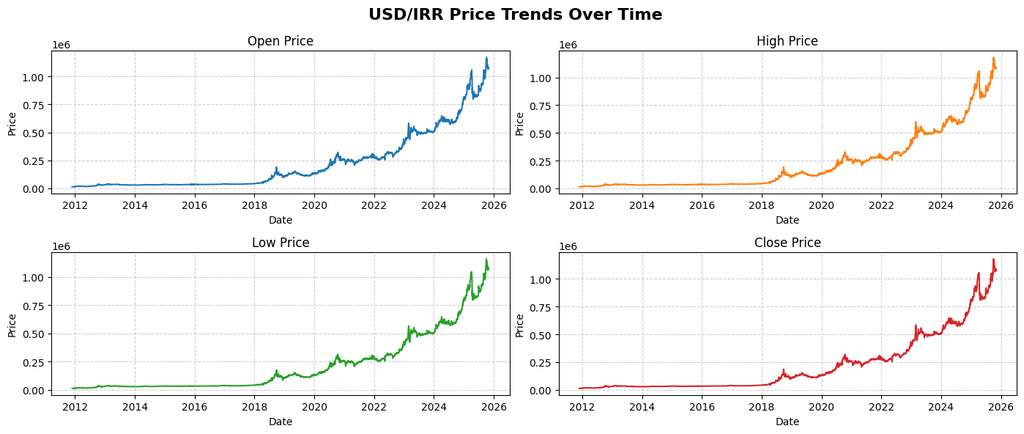

```python
# Plot price trends over time

# Define the price columns
price_columns = ['open_price', 'high_price', 'low_price', 'close_price']

# Create subplots: 2 rows, 2 columns
fig, axes = plt.subplots(nrows=2, ncols=2, figsize=(14, 6))
axes = axes.flatten()  # Flatten to easily iterate
colors = ['tab:blue', 'tab:orange', 'tab:green', 'tab:red']

# Loop through columns and axes
for i, col in enumerate(price_columns):
    axes[i].plot(df.index, df[col], color=colors[i])
    axes[i].set_title(f'{col.replace("_", " ").title()}')
    axes[i].set_xlabel('Date')
    axes[i].set_ylabel('Price')
    axes[i].grid(True, linestyle='--', alpha=0.6)

# Add one big title for the entire figure
fig.suptitle('USD/IRR Price Trends Over Time', fontsize=16, fontweight='bold')

# Adjust layout for better spacing
plt.tight_layout()
plt.show()
```

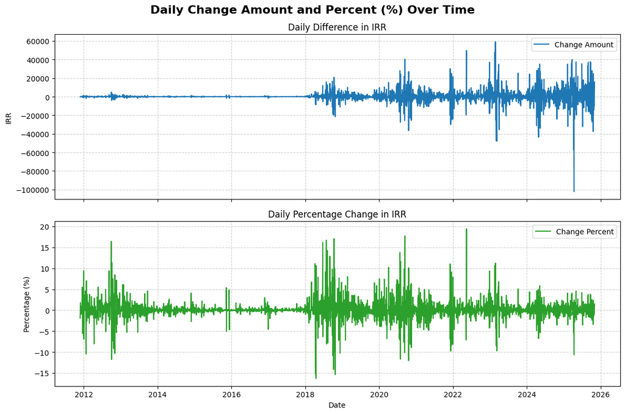

```
Change Amount: Min = -102,250.00, Max = 59,099.00
Change Percent: Min = -16.32%, Max = 19.45%
```

```python
# Plot Change & Percent Amounts over time

# Create subplots: 2 rows, 1 column
fig, axes = plt.subplots(nrows=2, ncols=1, figsize=(12, 8), sharex=True)

# Plot change amount
axes[0].plot(df.index, df['change_amount'], color='tab:blue', label='Change Amount')
axes[0].set_title('Daily Difference in IRR') # Daily Change Amount
axes[0].set_ylabel('IRR')
axes[0].grid(True, linestyle='--', alpha=0.6)
axes[0].legend()

# Plot change percent
axes[1].plot(df.index, df['change_percent'], color='tab:green', label='Change Percent')
axes[1].set_title('Daily Percentage Change in IRR') # Daily Change Percent
axes[1].set_ylabel('Percentage (%)')
axes[1].grid(True, linestyle='--', alpha=0.6)
axes[1].legend()

# Set the x-axis label for the bottom plot
axes[1].set_xlabel('Date')
fig.suptitle('Daily Change Amount and Percent (%) Over Time', fontsize=16, fontweight='bold')
plt.tight_layout()
plt.show()

# Print the min and max of change_amount and change_percent
print(f"Change Amount: Min = {df['change_amount'].min():,.2f}, Max = {df['change_amount'].max():,.2f}")
print(f"Change Percent: Min = {df['change_percent'].min():.2f}%, Max = {df['change_percent'].max():.2f}%")
```

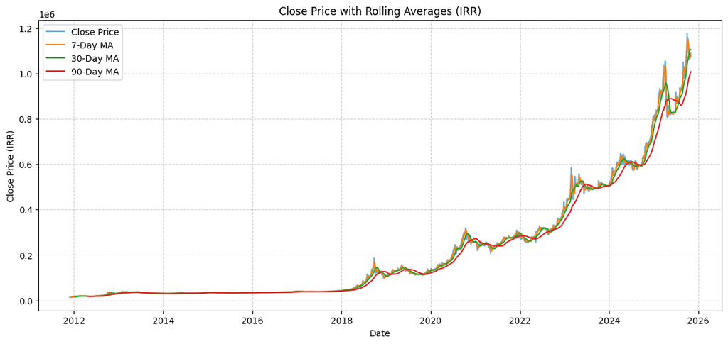

```python
# Calculate rolling averages for 'close_price' (this will introduce NaN values at the start)

# Define rolling window sizes
rolling_windows = [7, 30, 90]

# Calculate rolling averages and add as new columns
for window in rolling_windows:
    df[f'close_price_ma_{window}'] = df['close_price'].rolling(window=window).mean()

# Plot close price with rolling averages
plt.figure(figsize=(14, 6))
plt.plot(df.index, df['close_price'], label='Close Price', alpha=0.6)
for window in rolling_windows:
    plt.plot(df.index, df[f'close_price_ma_{window}'], label=f'{window}-Day MA')
plt.title('Close Price with Rolling Averages (IRR)')
plt.xlabel('Date')
plt.ylabel('Close Price (IRR)')
plt.legend()
plt.grid(True, linestyle='--', alpha=0.6)
plt.show()

# Drop the rolling average columns
df.drop(columns=['close_price_ma_7', 'close_price_ma_30', 'close_price_ma_90'], inplace=True)
```

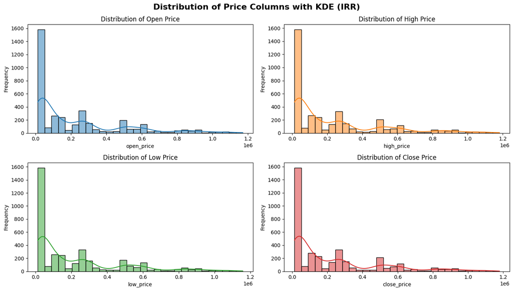

```python
# Plot the distribution of price columns (histograms and KDE)

# 'price_columns' & 'colors' are already defined above

# Create subplots: 2 rows, 2 columns
fig, axes = plt.subplots(nrows=2, ncols=2, figsize=(14, 8))
axes = axes.flatten()

for i, col in enumerate(price_columns):
    sns.histplot(df[col], bins=30, kde=True, color=colors[i], edgecolor='black', ax=axes[i])
    axes[i].set_title(f'Distribution of {col.replace("_", " ").title()}', fontsize=12)
    axes[i].set_xlabel(col)
    axes[i].set_ylabel('Frequency')

plt.suptitle('Distribution of Price Columns with KDE (IRR)', fontsize=16, fontweight='bold')
plt.tight_layout(rect=[0, 0, 1, 1])
plt.show()
```

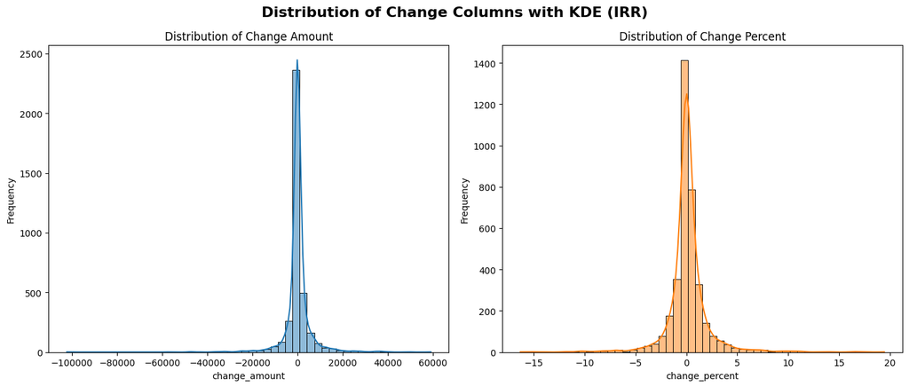

```python
# Plot the distribution of change columns (histograms and KDE)

# 'colors' is already defined above

# Create 2 plots side by side
fig, axes = plt.subplots(nrows=1, ncols=2, figsize=(14, 6))

for i, col in enumerate(['change_amount', 'change_percent']):
    sns.histplot(df[col], bins=50, kde=True, color=colors[i], edgecolor='black', ax=axes[i])
    axes[i].set_title(f'Distribution of {col.replace("_", " ").title()}', fontsize=12)
    axes[i].set_xlabel(col)
    axes[i].set_ylabel('Frequency')

plt.suptitle('Distribution of Change Columns with KDE (IRR)', fontsize=16, fontweight='bold')
plt.tight_layout(rect=[0, 0, 1, 1])
plt.show()
```

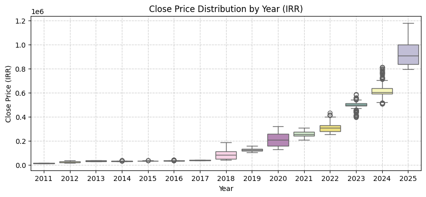

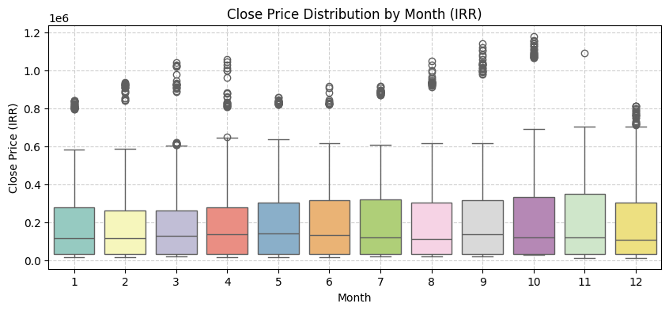

```
Yearly Close Price Summary (IRR):
```

| year | count | mean | std | min | 25% | 50% | 75% | max |
| --- | --- | --- | --- | --- | --- | --- | --- | --- |
| 2011 | 21.0 | 14315.62 | 832.48 | 13350.0 | 13590.0 | 14080.0 | 15150.00 | 15900.0 |
| 2012 | 245.0 | 22833.07 | 6005.72 | 15750.0 | 18500.0 | 19430.0 | 29050.00 | 36100.0 |
| 2013 | 234.0 | 33068.00 | 2613.25 | 29150.0 | 30412.5 | 32900.0 | 35387.50 | 38830.0 |
| 2014 | 284.0 | 31737.92 | 1400.27 | 29340.0 | 30877.5 | 31745.0 | 32520.00 | 35590.0 |
| 2015 | 249.0 | 33671.98 | 647.72 | 32140.0 | 33190.0 | 33836.0 | 33981.00 | 35750.0 |
| 2016 | 239.0 | 35388.85 | 1513.53 | 33800.0 | 34505.0 | 34970.0 | 35749.50 | 41210.0 |
| 2017 | 238.0 | 38820.84 | 1480.41 | 37240.0 | 37650.0 | 38210.0 | 39757.25 | 42880.0 |
| 2018 | 274.0 | 86743.39 | 34731.73 | 43283.0 | 51022.5 | 81520.0 | 114142.50 | 186680.0 |
| 2019 | 283.0 | 124892.92 | 10799.99 | 104500.0 | 115075.0 | 124020.0 | 131955.00 | 156010.0 |
| 2020 | 286.0 | 207748.73 | 54152.06 | 129500.0 | 157002.5 | 208210.0 | 257755.00 | 318526.0 |
| 2021 | 284.0 | 258870.22 | 21572.67 | 206480.0 | 242287.5 | 253720.0 | 275817.50 | 309710.0 |
| 2022 | 268.0 | 309168.25 | 37573.02 | 254170.0 | 277872.5 | 308730.0 | 327985.00 | 434360.0 |
| 2023 | 274.0 | 496442.77 | 29630.80 | 394830.0 | 490882.5 | 500825.0 | 511080.00 | 584930.0 |
| 2024 | 287.0 | 620827.86 | 60247.57 | 506430.0 | 590200.0 | 604850.0 | 637700.00 | 813200.0 |
| 2025 | 228.0 | 924703.07 | 99353.69 | 793450.0 | 834650.0 | 907200.0 | 998387.50 | 1178600.0 |

```
Monthly Close Price Summary (IRR):
```

| month | count | mean | std | min | 25% | 50% | 75% | max |
| --- | --- | --- | --- | --- | --- | --- | --- | --- |
| 1 | 325.0 | 208615.77 | 234920.85 | 15800.0 | 34600.00 | 114500.0 | 278820.00 | 839300.0 |
| 2 | 288.0 | 215819.57 | 260912.93 | 17830.0 | 34498.00 | 116800.0 | 261475.00 | 935800.0 |
| 3 | 272.0 | 224395.77 | 270773.73 | 18520.0 | 34262.25 | 128860.0 | 262575.00 | 1038950.0 |
| 4 | 304.0 | 230254.14 | 266280.57 | 17100.0 | 34630.00 | 136165.0 | 278772.50 | 1055550.0 |
| 5 | 330.0 | 229446.65 | 255622.89 | 15750.0 | 34542.50 | 141416.0 | 304924.25 | 858700.0 |
| 6 | 279.0 | 215106.77 | 234062.63 | 17600.0 | 34515.00 | 131350.0 | 316825.00 | 917200.0 |
| 7 | 319.0 | 233893.74 | 256474.56 | 18990.0 | 33107.00 | 120240.0 | 319062.00 | 916000.0 |
| 8 | 321.0 | 241271.41 | 270042.44 | 20190.0 | 33558.00 | 113010.0 | 303110.00 | 1048300.0 |
| 9 | 309.0 | 256039.30 | 287139.69 | 21590.0 | 33930.00 | 137600.0 | 315560.00 | 1141300.0 |
| 10 | 327.0 | 274839.33 | 312038.04 | 29950.0 | 34600.00 | 121900.0 | 331115.00 | 1178600.0 |
| 11 | 299.0 | 213970.88 | 217212.31 | 13350.0 | 33940.00 | 120300.0 | 348607.00 | 1088700.0 |
| 12 | 321.0 | 208474.84 | 224193.55 | 13450.0 | 33970.00 | 108190.0 | 303380.00 | 813200.0 |

```python
# Plot close price distribution by year and month

# Extract year and month from the index
df['year'] = df.index.year
df['month'] = df.index.month

# Boxplot of close price by year
plt.figure(figsize=(10, 4))
sns.boxplot(x='year', y='close_price', data=df, palette='Set3')
plt.title('Close Price Distribution by Year (IRR)')
plt.xlabel('Year')
plt.ylabel('Close Price (IRR)')
plt.grid(True, linestyle='--', alpha=0.6)
plt.show()

# Boxplot of close price by month
plt.figure(figsize=(10, 4))
sns.boxplot(x='month', y='close_price', data=df, palette='Set3')
plt.title('Close Price Distribution by Month (IRR)')
plt.xlabel('Month')
plt.ylabel('Close Price (IRR)')
plt.grid(True, linestyle='--', alpha=0.6)

plt.show()

# Print statistical summary by year and month
yearly_summary = df.groupby('year')['close_price'].describe().round(2)
monthly_summary = df.groupby('month')['close_price'].describe().round(2)

# Print in a pretty format
print("Yearly Close Price Summary (IRR):")
display(yearly_summary)
print("\nMonthly Close Price Summary (IRR):")
display(monthly_summary)

# Drop year and month columns as they were only needed for grouping
df.drop(columns=['year', 'month'], inplace=True)
```

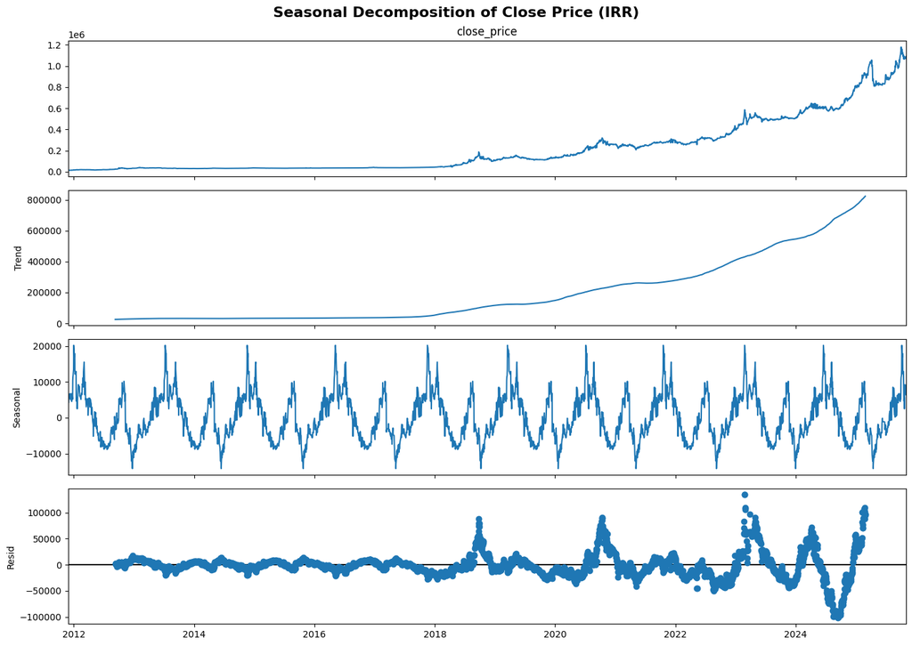

[output not shown]

```python
from statsmodels.tsa.seasonal import seasonal_decompose             # Seasonal decomposition of time series

# Plot seasonal decomposition of close price
decomposition = seasonal_decompose(df['close_price'], model='additive', period=365)

fig = decomposition.plot()
fig.set_size_inches(14, 10)
plt.suptitle('Seasonal Decomposition of Close Price (IRR)', fontsize=16, fontweight='bold')
plt.tight_layout(rect=[0, 0, 1, 1])
plt.show()

'''
    In additive seasonal decomposition, the model computes: --> 'Close Price' = Trend + Seasonal + Residual
    - Trend: The long-term progression of the series (overall increase in close price over years).
    - Seasonal: The repeating short-term cycle (monthly patterns in close price).
    - Residual: The random noise left after removing trend and seasonal components.

    Residual --> Residual = Observed − (Trend + Seasonal)
'''
```

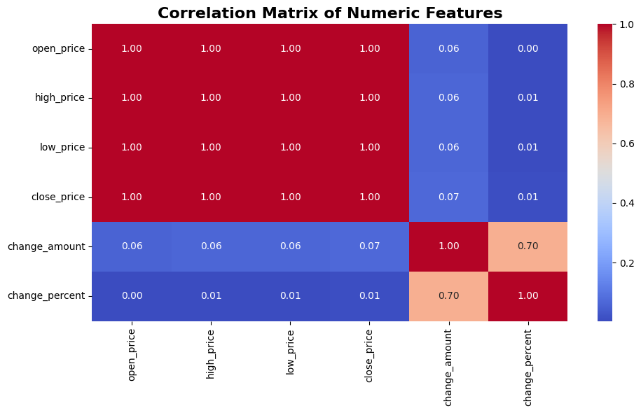

```python
# Compute Correlation Matrix (Pearson correlations)
corr_matrix = df[['open_price', 'high_price', 'low_price', 'close_price', 'change_amount', 'change_percent']].corr()

# Plot the correlation matrix heatmap
plt.figure(figsize=(10, 6))
sns.heatmap(corr_matrix, annot=True, fmt=".2f", cmap='coolwarm')
plt.title('Correlation Matrix of Numeric Features', fontsize=16, fontweight='bold')
plt.tight_layout()
plt.show()
```

```python
# Drop open_price, high_price, low_price as they are highly correlated with close_price
df.drop(columns=['open_price', 'high_price', 'low_price'], inplace=True)

df.info()
```

```
<class 'pandas.core.frame.DataFrame'>
DatetimeIndex: 3694 entries, 2011-11-27 to 2025-11-01
Data columns (total 3 columns):
 #   Column          Non-Null Count  Dtype
---  ------          --------------  -----
 0   close_price     3694 non-null   int64
 1   change_amount   3694 non-null   float64
 2   change_percent  3694 non-null   float64
dtypes: float64(2), int64(1)
memory usage: 244.5 KB
```